# Data Story 2

2026-02-26

## Main Focus: Extreme Poverty

According to Our World In Data, extreme poverty is defined as living below the international poverty line of $3 per day.

### **Key Objectives**:

- *Objective 1*: Exploring global extreme poverty rates
- *Objective 2*: Using malnourishment data
- *Objective 3*: Incorporating accessibility to clean drinking water data
- *Objective 4*: Is there a connection between extreme poverty and armed conflict?

## Sustainable Development Goals

- SDG 1: **No Poverty**
- SDG 2: **Zero Hunger**
- SDG 6: **Clean Water and Sanitation**

*All data used for this data story was found from Our World In Data.*

## Exploring The Data

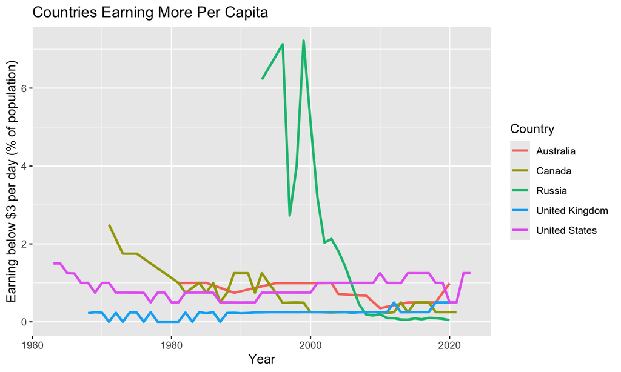

## Exploring The Data

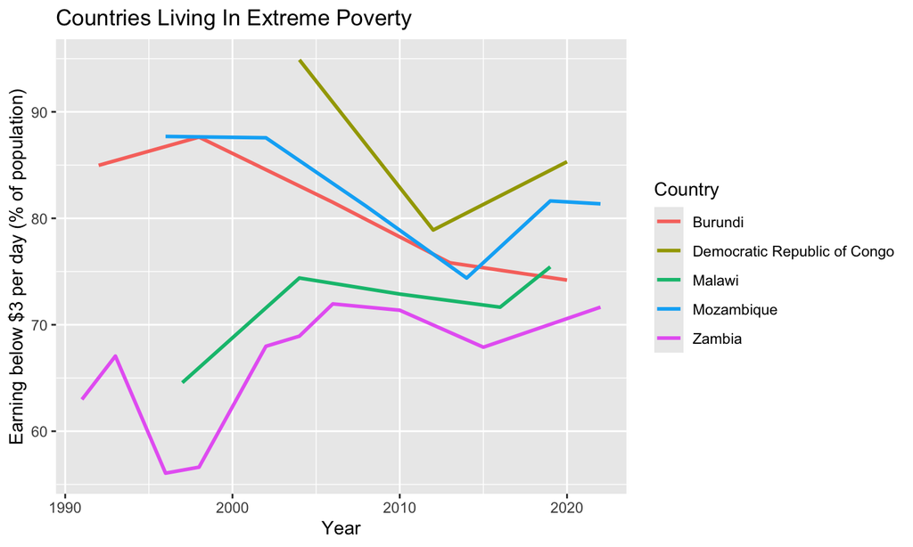

## Exploring The Data

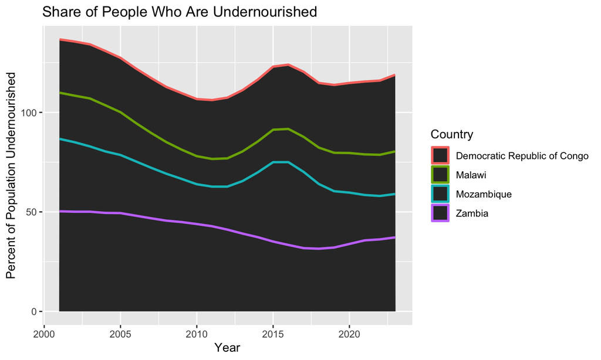

## Exploring The Data

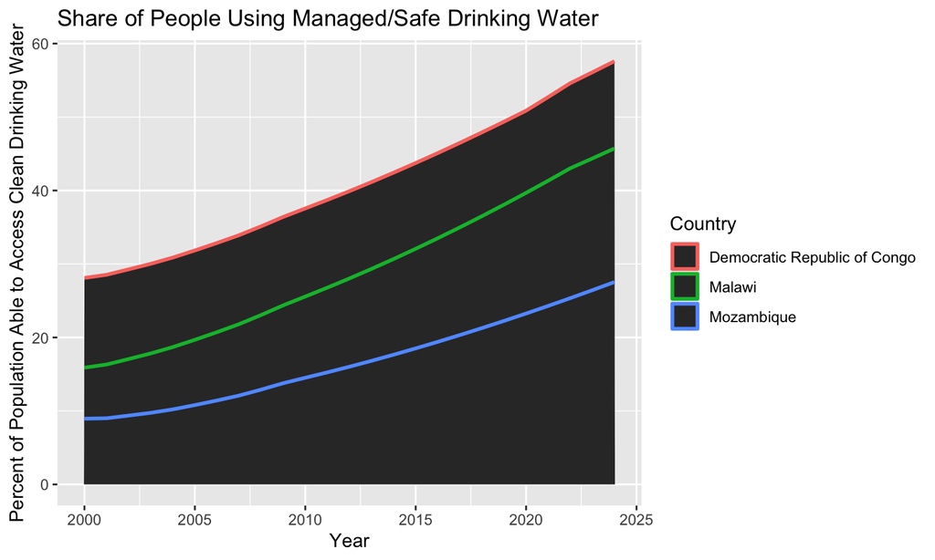

## Exploring The Data

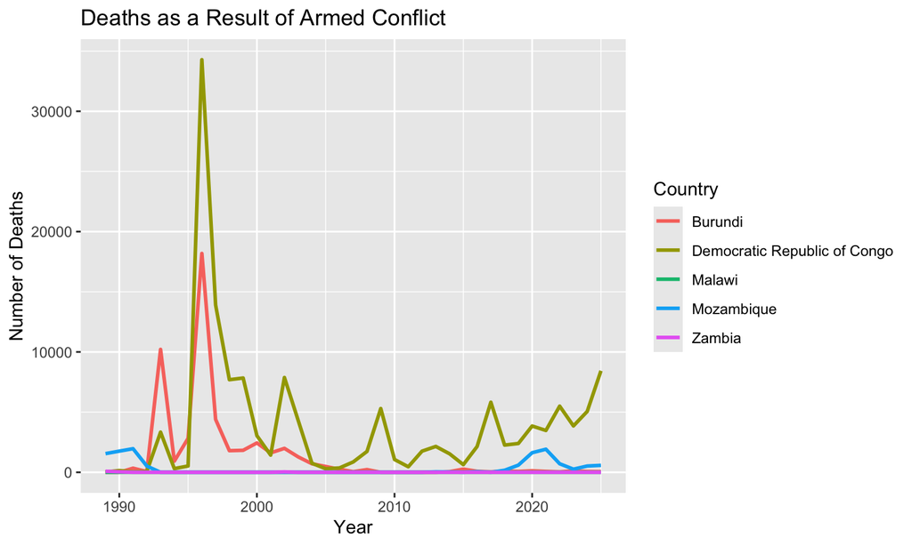

## Conclusion

- Clear connection between extreme poverty and malnourishment.
- People using managed/safe drinking water has been increasing since the early 2000s for most impoverished countries.
- The connection between extreme poverty and deaths as a result of armed conflict is more unclear. These regions experiencing extreme poverty have had armed conflict situations yet it may not have as direct of an impact on poverty. This is a misconception that many people, including myself fell victim to.